# Projeto 2: Regressão do Preço de Imóveis

Marjorie Hoegen

Problema: previsão do preço do imóvel baseado nos dados de vendas passadas. Assumindo que eu tenha um imóvel com área de 200 m² como saber quanto vale meu imóvel baseado em dados históricos?

O primeiro passo para a resolução deste problema é visualizar os dados disponíveis.

```r
housingSmall <- read.csv2("~/Faculdade/2018.1/Optativa/projeto2/housingSmall.txt")
hr <- housingSmall

#Ajustar os nomes das colunas

colnames(hr)[2] = "area"
colnames(hr)[3] = "garagem"
colnames(hr)[4] = "quartos"
colnames(hr)[5] = "preco"

#Visualizando os dados através de um gráfico

g <- ggplot(data = hr, aes(x=area, y=preco))
g <- g + geom_point() + labs(title = "Preços de venda de imóveis", y="Preço (x R$1000,00)", x="Área (x 100m2)")
```

Uma maneira de analisar a relação entre o preço e a área do imóvel é através de uma regressão linear.

### Modelo inicial: Regressão linear

Para ajustar um modelo de regressão linear em R utiliza-se a função *lm()*.

```r
hr_lm <- lm(data = hr, preco ~ area)
```

Com isso, obtemos os coeficientes da reta, estimados pelo método dos mínimos quadrados.

```r
summary(hr_lm)
```

```
##
## Call:
## lm(formula = preco ~ area, data = hr)
##
## Residuals:
##     Min      1Q  Median      3Q     Max
## -70.447 -23.275   5.113  20.374  54.598
##
## Coefficients:
##             Estimate Std. Error t value Pr(>|t|)
## (Intercept)   100.67      43.45   2.317   0.0390 *
## area           55.22      25.31   2.182   0.0497 *
## ---
## Signif. codes:  0 '***' 0.001 '**' 0.01 '*' 0.05 '.' 0.1 ' ' 1
##
## Residual standard error: 40.38 on 12 degrees of freedom
## Multiple R-squared:  0.284,  Adjusted R-squared:  0.2243
## F-statistic:  4.76 on 1 and 12 DF,  p-value: 0.04974
```

Portanto, a equação nesse caso seria: y = 55.22x + 100.67

Podemos notar que essa regressão apresentou um R quadrado baixo (28.4%), que é o quanto a variável independente é capaz de representar a variável dependente.

Também é possível fazer a regressão diretamente através do ggplot obtendo assim um gráfico da reta.

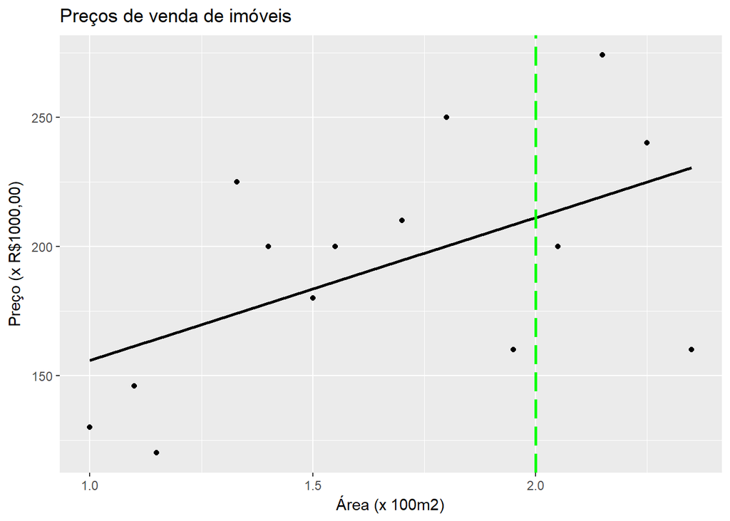

```r
g1 <- g +
  stat_smooth(method = lm, se = FALSE, formula = y ~ x, colour = "Black", linetype = "solid") +
  geom_vline(xintercept = 2.0, size = 1, colour = "green", linetype = "longdash")
```

Com a regressão linear obtida, podemos fazer a análise dos resíduos, que são as diferenças entre os dados de fato e o que foi estimado.

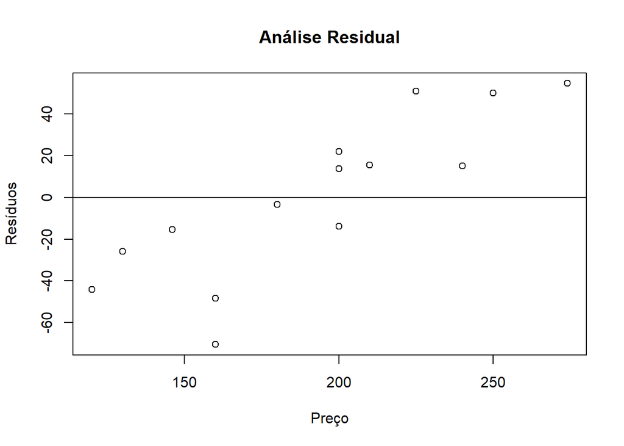

```r
reg_resid <- resid(hr_lm)
plot(hr$preco, reg_resid, ylab = "Resíduos", xlab = "Preço", main = "Análise Residual")
abline(0,0)
```

Neste caso, observa-se que vários resíduos não estão próximos ao eixo horizontal, o que indica que o modelo não é adequado.